# **Introduction to Neural Networks**

- Artificial Neural Networks (ANN) are one of the most widely used machine learning algorithms in the field of data science and analytics.
- Neural networks mimic the complex functions of the human brain. These models consist of interconnected nodes or neurons that process data, learn patterns, and enable tasks such as pattern recognition and decision-making.
- The concept of neural networks evolved from the [Perceptron](https://towardsdatascience.com/what-is-a-perceptron-basics-of-neural-networks-c4cfea20c590/), a key machine learning algorithm. For this reason, Neural Networks are also called Multi-Layer Perceptrons (MLP).
- There exist different types of neural networks sharing common fundamental components used for different purposes, which include:
1. **Neurons**: The basic units, analogous to a biological neuron, that receive inputs, perform calculations, and produce an output.
2. **Connections**: Links between neurons, analogous to a biological synapse between neurons, that carry information, regulated by weights and biases.
3. **Weights and Biases**: These parameters determine the strength and influence of connections.
4. **Learning Rate**: The method that adjusts weights and biases over time to improve accuracy.
1. **NEURON**

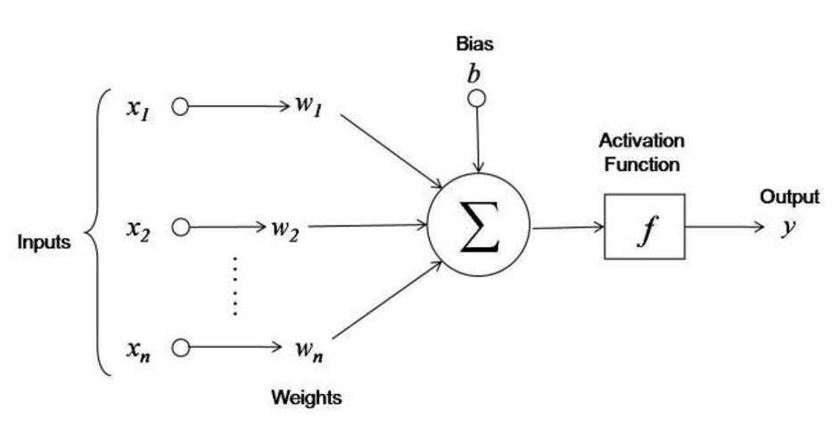

Neuron, on the fundamental level, is an algorithm of supervised machine learning, with a design that serves as the building block for complex deep learning algorithms.

To put it simply, a neuron calculates the ‘weighted sum’ of its inputs, adds a bias, then passes this net input to an activation function, which in turn decides whether a neuron should be activated or not and how much information should pass through it.

$Output = Activation\ function(\ \sum_{}^{}(Weight\ \times Input\ ) + Bias)$

1.1 **Weights**

Weights refer to the factors by which the features ( X<sub>i</sub> ) are scaled before addition. They signify the relative influence of a specific feature on estimating the final result and the direction of said influence.

A larger weight (in magnitude) means that the corresponding input has more influence. Also, a positive weight means the input increases the neuron's output; a negative weight causes the output to decrease.

1.2 **Bias**

Bias acts like the intercept ‘c’ in a linear equation,$y = mx + c'\ \$i.e., a bias prevents the neuron from turning ‘off ’ (generating a zero output value), should all the input values drop to zero.

It enables the network to fit patterns (functions) that don’t pass through the origin. Also, it enables activation functions like ReLU, sigmoid, etc, to activate at different thresholds.

1.3 **Activation Functions**:

**What?**

Activation functions are mathematical functions that can be used to introduce non–linearity into the neural networks.

**Why?**

If we do not include non–linear activation functions (like ReLU, Sigmoid), our network will be able to learn only linear patterns in the input data, resulting in poor predictions.

With appropriate activation functions and suitable architecture, a neural network can approximate any continuous function, due to the [Universal Approximation Theorem](http://neuralnetworksanddeeplearning.com/chap4.html).

**2. Neural Network Architecture**

1. **Overview of Fundamentals**

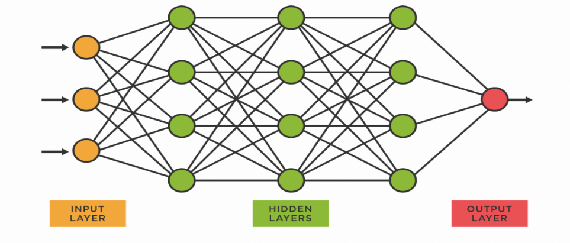

- Input Layer

It refers to the first layer in the neural network, which accepts inputs as raw data with each node representing a feature value.

- Hidden Layer

It refers to one or more layers between the input and output layers.

This is where the **Learning** happens (i.e., patterns are detected in the data). Each layer accepts the input data, draws insights from it, generates an output, and sends it to the next layer.

The type of layer varies depending on the requirements of the neural network. Some of which include:

1. Dense
2. Convolutional
3. Recurrent
4. Dropout
5. Embedding
- Output Layer

It refers to the last layer of the neural network, usually consisting of an activation function that processes the raw output to either a single vector (in case of regression problems) or class probabilities (in case of classification problems).

**Note:** When we say N-layer neural network, we do not count the input layer.

**2.2 Different Architecture Types**

**2.2.1 Feedforward Neural Network**

A Feed-Forward Neural Network is an artificial neural network in which the connections between nodes do not form cycles.

In a feedforward neural network, the input data is passed through the network, and each neuron in the hidden layer(s) performs a weighted sum of the inputs, applies an activation function, and passes the output to the next layer.

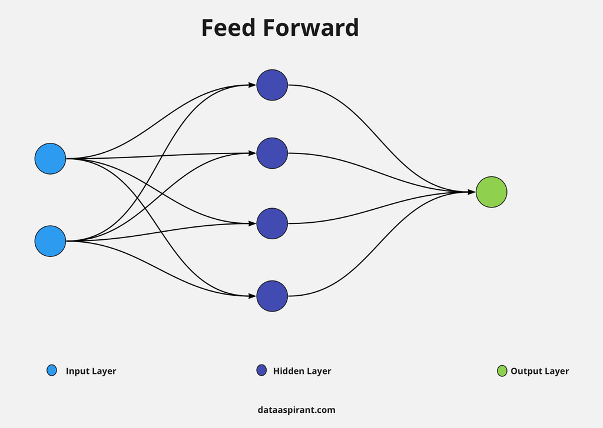

**2.2.2 Recurrent Neural Network**

A recurrent neural network, or RNN, is a model trained on sequential or time series data that can make sequential predictions based on sequential inputs. They are distinguished by their “memory” as they take information from prior inputs to influence the current input and output.

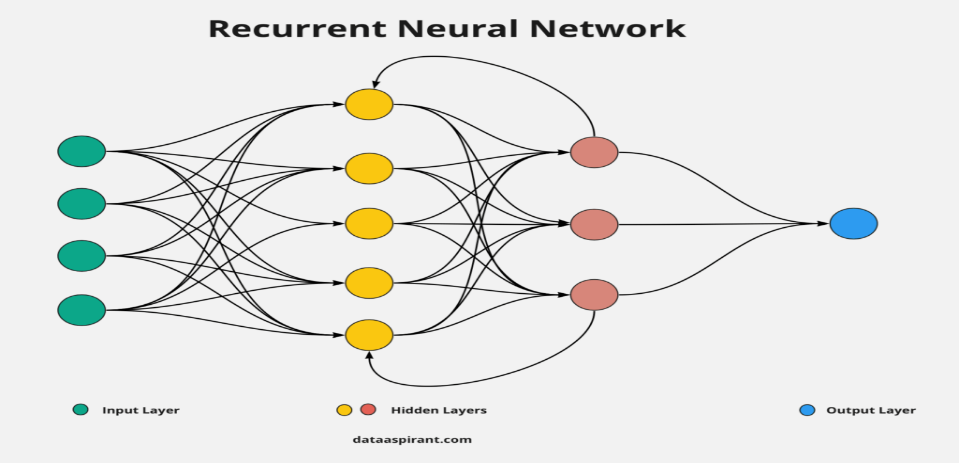

3. **Activation functions**

As mentioned above, activation functions introduce non–linearity into the neural networks, allowing them to fit complex functions to the testing data. However, different activation functions serve different purposes; hence, a combination of correct activation functions must be chosen while constructing a neural network. The most commonly used activation functions are:

1. Sigmoid
2. Hyperbolic tangent (tanh)
3. Regulated Linear Unit (ReLU) and its variations
4. Softplus

**3.1 Sigmoid**

**3.1.1 Overview**

The Sigmoid function is an S-shaped (sigmoidal) function that maps any real-valued number to a range between 0 and 1, with the following formula and plot:

$\sigma(x) = \frac{1}{1 + e^{- x}}$

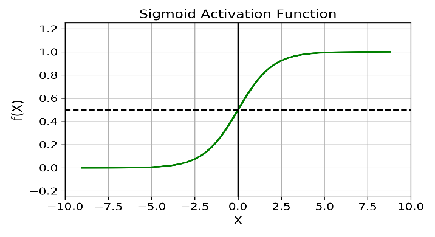

**3.1.2 Advantages**

1. Since it gives values in the range of [0,1), it is suitable for representing probabilities. So, it is often used in binary classification tasks and the logistic regression algorithm.

2. It is differentiable over the entire domain, so it helps in small and fine updates during gradient descent.

**3.1.3 Disadvantages**

1. **Vanishing Gradient Problem:** Gradients become very small when inputs are far from 0; as a result, weights and biases change slowly, resulting in inefficient networks.

2. **Not Zero–Centred:** Outputs are between [0, 1], so gradients can be biased in a particular direction.

**3.2 Hyperbolic Tangent (tanh)**

**3.2.1 Overview**

The tanh function (short for hyperbolic tangent) is an S-shaped activation function like sigmoid (in a shifted and scaled form), but it maps input values in a range between **-**1 and 1. It is defined mathematically as

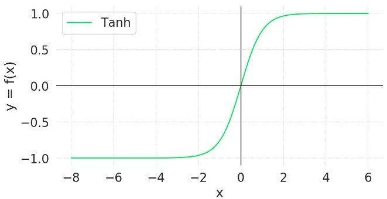

**3.2.2 Advantages**

1. The function is better than sigmoid as it is zero–centred and has a wider output range while also being differentiable in the entire domain.

**3.2.3 Disadvantages**

1. The tanh function also suffers from the vanishing gradient problem, especially in the case of deep networks (with more layers).

**3.3 Regulated Linear Unit (ReLU) and its variants**

**3.3.1 Overview**

ReLU allows positive values to pass through unchanged while setting all negative values to zero.This helps the neural network in maintaining the necessary complexity to learn patterns while avoiding some of the pitfalls associated with other activation functions. It is defined mathematically as

$f(x) = max(0,x)$

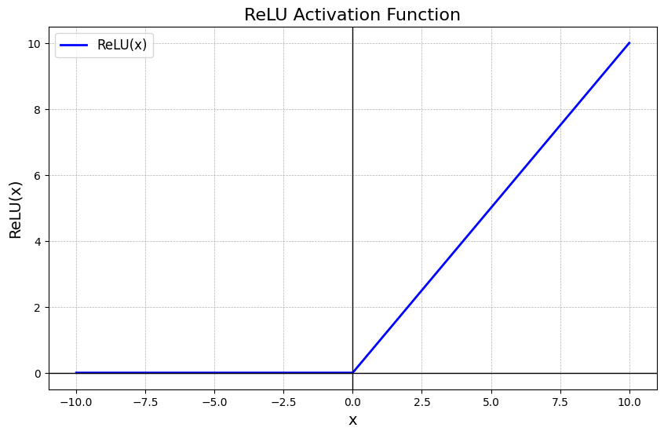

**3.3.2 Advantages**

1. ReLU, however, avoids the vanishing gradient problem as its derivative is either 0 or 1, implying that a neuron can either be ‘on’ or ‘off’.

2. It is one of the simplest nonlinear functions, making it computationally efficient. This simplicity makes it easy to implement and compute while constructing deep networks with a plethora of weights and biases.

**3.3.3 Disadvantages**

1. **Dying ReLU Problem:** One of the most significant drawbacks of ReLU is the ‘dying ReLU’ problem, where neurons can sometimes become inactive and only produce zero output. This happens when large negative inputs result in zero gradient, leading to a neuron that never activates and cannot learn further. This is solved by making a slight variation in the ReLU function.
2. **Exploding Gradient Problem:** Unlike other activation functions like sigmoid or tanh, the ReLU activation is unbounded on the positive side, which can sometimes result in exploding gradients when training deep networks.
3. **Noisy Gradients:** The gradient of ReLU can be unstable during training, especially when weights are not properly initialized. In some cases, this can hamper learning or lead to poor performance.

**3.3.4 Variations**

The variations of the ReLU function help to solve some of the issues, like ‘dying ReLU’, present in the network.

**1. Leaky ReLU**

Leaky ReLU introduces a small slope for negative values instead of outputting zero, which prevents neurons from ‘dying’, and avoids lag in learning. It is defined mathematically as

$f(x)\ = \ \{\ x,\ if\ \ \ x\ > \ 0\ ;\ \alpha x\ ,\ if\ \ x\ \leq \ 0$} , where $\alpha$ is a small positive constant (often set to 0.01)

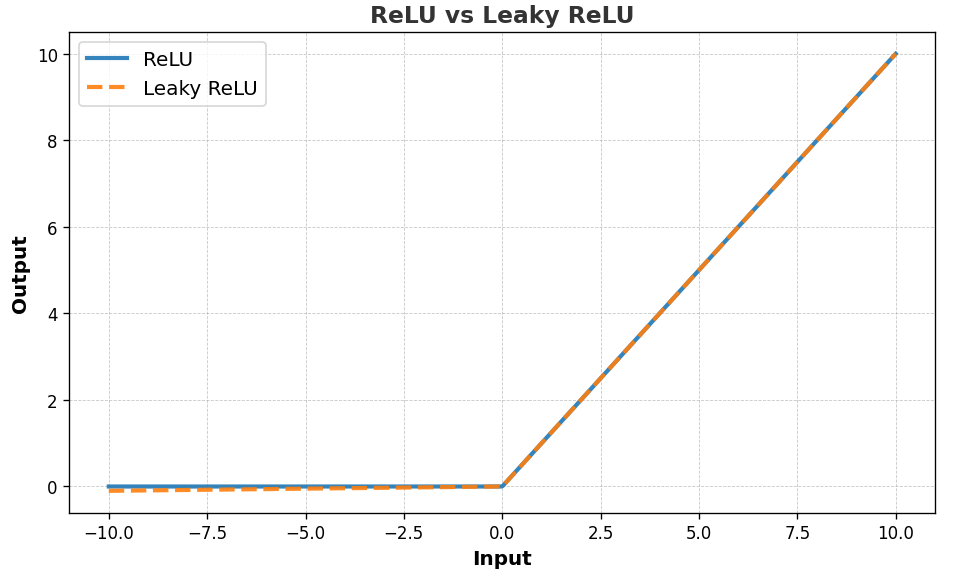

**2. Parametric ReLU (PReLU)**

PReLU is exactly the same as Leaky ReLU, the only difference being that instead of the parameter $\alpha$ being pre-initialised, it is learnt during training. Hence, it is more flexible than Leaky ReLU.

**3. Exponential Linear Unit (ELU)**

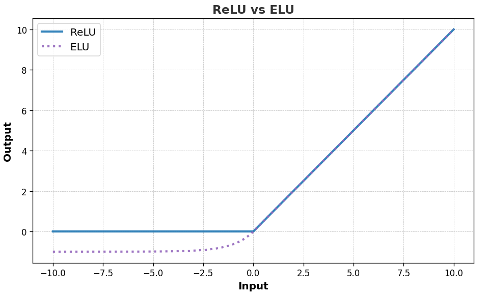

**3.4 Softplus**

**3.4.1 Overview**

The Softplus function is a smooth approximation of the ReLU function. It is defined mathematically as

$f(x) = ln(1 + e^{x})$

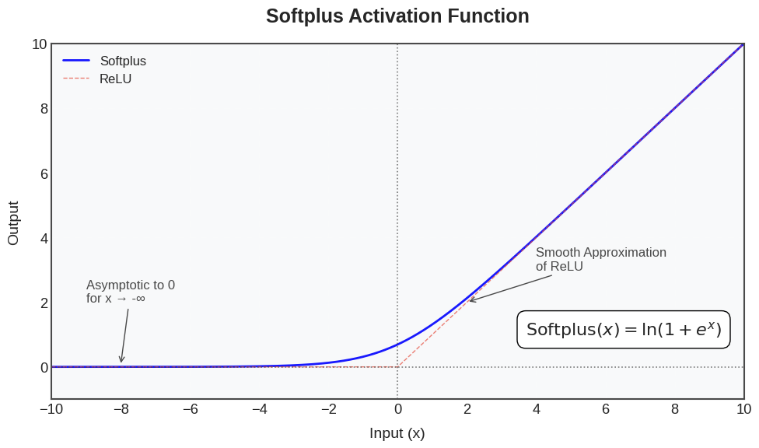

Its output is always positive. The function smoothly increases and is always differentiable, unlike ReLU, which has a sharp corner at zero.

**3.4.2 Advantages**

1. **Preventing Dying Neurons**: The ReLU function causes neurons to ‘die’ if they output negative values. Softplus avoids this by providing a smooth, continuous output for both positive and negative inputs, as it approaches zero gradually as input decreases.

2**. Numerical Stability**: The Softplus function has better numerical stability than some of the other activation functions because it avoids the issues that arise from very large or very small values. It has a smooth output, and for very large or very small inputs, the function behaves predictably, reducing the risk of overflow or underflow in computations.

**3.4.3 Disadvantages**

1. **Computationally More Expensive:** Since Softplus involves logarithmic and exponential calculations, it is computationally more expensive than ReLU. This can slow down training for large networks, especially in resource-limited systems.

2. **Slower Convergence**: The smoother nature of Softplus can sometimes lead to slower convergence during training as compared to ReLU.